# Relationship between Harzard Type and Damage of Population Health and Economy

Runze Huang

October 27, 2016

## Synopsis

To provide information about which type of event might lead to most population health harm and economic damage. I used the data from the U.S. National Oceanic and Atmospheric Administration’s (NOAA) storm database. To evaluate the harm to population health, total fatalities and injuries were taken into analysis. To evaluate the economic damage, property damage and crop damage were taken into analysis. In conclusion, tornado was the most harmful type of event to population health and flood caused the most economic damage.

## Data Processing

Load the data and cache to avoid long time reloading for trials.

```r
  data_raw <- read.csv("repdata%2Fdata%2FStormData.csv.bz2")
```

## Results

### Question 1: Across the United States, which types of events (as indicated in the EVTYPE variable) are most harmful with respect to population health?

As there are two variables related to the population health, I evaluated the total fatalities and total injuries classified by event type and plotted the top 20 types as to fatalities or injuries.

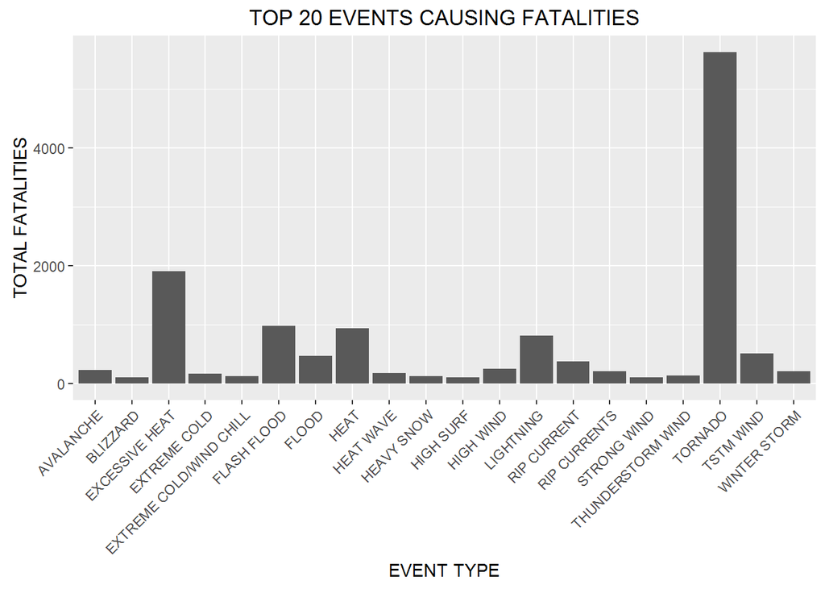

```r
  library(ggplot2)
  data_fatalities <- aggregate(FATALITIES ~ EVTYPE, data = data_raw, FUN = sum)
  data_fatalities_descending <- data_fatalities[order(-data_fatalities$FATALITIES), ]
  bar_fatalities <- ggplot(data = data_fatalities_descending[1:20, ], aes(x = EVTYPE, y = FATALITIES)) + geom_bar(stat = "identity") + theme(axis.text.x=element_text(angle=45, hjust=1)) + labs(title = "TOP 20 EVENTS CAUSING FATALITIES", x = "EVENT TYPE", y = "TOTAL FATALITIES")
  bar_fatalities
```

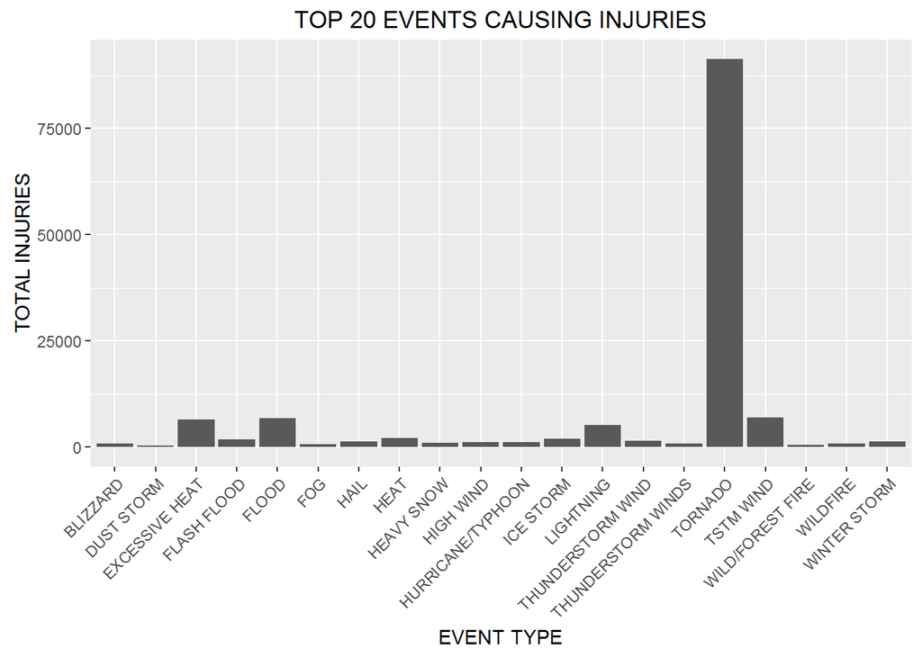

```r
  data_injuries <- aggregate(INJURIES ~ EVTYPE, data = data_raw, FUN = sum)
  data_injuries_descending <- data_injuries[order(-data_injuries$INJURIES), ]
  bar_injuries <- ggplot(data = data_injuries_descending[1:20, ], aes(x = EVTYPE, y = INJURIES)) + geom_bar(stat = "identity") + theme(axis.text.x=element_text(angle=45, hjust=1)) + labs(title = "TOP 20 EVENTS CAUSING INJURIES", x = "EVENT TYPE", y = "TOTAL INJURIES")
  bar_injuries
```

From the figure above, we could see that tornado was the most harmful type of event to population health in terms of fatalities or injuries.

### Question 2: Across the United States, which types of events have the greatest economic consequences?

As the property damage and crop damage data were stored with exponentials, I need to calculate the actual damage to evalaute which types of events have the greatest economic consequences. And then I add the actual damage of property and crops to evaluate the economic damage.

```r
  data_raw$PROPDMG2 <- NA
  data_raw[data_raw$PROPDMGEXP == "h", ]$PROPDMG2 <- data_raw[data_raw$PROPDMGEXP == "h", ]$PROPDMG * 100
  data_raw[data_raw$PROPDMGEXP == "H", ]$PROPDMG2 <- data_raw[data_raw$PROPDMGEXP == "H", ]$PROPDMG * 100
  data_raw[data_raw$PROPDMGEXP == "K", ]$PROPDMG2 <- data_raw[data_raw$PROPDMGEXP == "K", ]$PROPDMG * 1000
  data_raw[data_raw$PROPDMGEXP == "m", ]$PROPDMG2 <- data_raw[data_raw$PROPDMGEXP == "m", ]$PROPDMG * 1000000
  data_raw[data_raw$PROPDMGEXP == "M", ]$PROPDMG2 <- data_raw[data_raw$PROPDMGEXP == "M", ]$PROPDMG * 1000000
  data_raw[data_raw$PROPDMGEXP == "B", ]$PROPDMG2 <- data_raw[data_raw$PROPDMGEXP == "B", ]$PROPDMG * 1000000000
  data_raw$CROPDMG2 <- NA
  data_raw[data_raw$CROPDMGEXP == "k", ]$CROPDMG2 <- data_raw[data_raw$CROPDMGEXP == "k", ]$CROPDMG * 1000
  data_raw[data_raw$CROPDMGEXP == "K", ]$CROPDMG2 <- data_raw[data_raw$CROPDMGEXP == "K", ]$CROPDMG * 1000
  data_raw[data_raw$CROPDMGEXP == "m", ]$CROPDMG2 <- data_raw[data_raw$CROPDMGEXP == "m", ]$CROPDMG * 1000000
  data_raw[data_raw$CROPDMGEXP == "M", ]$CROPDMG2 <- data_raw[data_raw$CROPDMGEXP == "M", ]$CROPDMG * 1000000
  data_raw[data_raw$CROPDMGEXP == "B", ]$CROPDMG2 <- data_raw[data_raw$CROPDMGEXP == "B", ]$CROPDMG * 1000000000
  data_raw$PROPDMG2[is.na(data_raw$PROPDMG2)] <- 0
  data_raw$CROPDMG2[is.na(data_raw$CROPDMG2)] <- 0
  data_raw$ECONDMG <- data_raw$PROPDMG2 + data_raw$CROPDMG2
```

And then I aggregated the economic damage by event type and used a bar plot to present it.

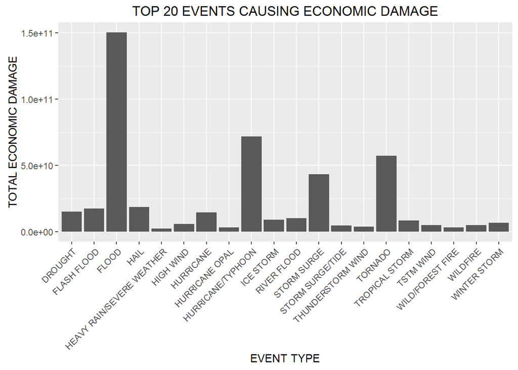

```r
  data_econdmg <- aggregate(ECONDMG ~ EVTYPE, data = data_raw, FUN = sum)
  data_econdmg_descending <- data_econdmg[order(-data_econdmg$ECONDMG), ]
  bar_econdmg <- ggplot(data = data_econdmg_descending[1:20, ], aes(x = EVTYPE, y = ECONDMG)) + geom_bar(stat = "identity") + theme(axis.text.x=element_text(angle=45, hjust=1)) + labs(title = "TOP 20 EVENTS CAUSING ECONOMIC DAMAGE", x = "EVENT TYPE", y = "TOTAL ECONOMIC DAMAGE")
  bar_econdmg
```

From the figure above, we could see that flood caused the most economic damage.